# Image Clustering Project

# Apriori algorithm

### rules for entire data set

```r
rules<-apriori(hashtags, parameter=list(supp=0.05, conf=1))
```

```
## Apriori
##
## Parameter specification:
##  confidence minval smax arem  aval originalSupport maxtime support minlen
##           1    0.1    1 none FALSE            TRUE       5    0.05      1
##  maxlen target  ext
##      10  rules TRUE
##
## Algorithmic control:
##  filter tree heap memopt load sort verbose
##     0.1 TRUE TRUE  FALSE TRUE    2    TRUE
##
## Absolute minimum support count: 5
##
## set item appearances ...[0 item(s)] done [0.00s].
## set transactions ...[1157 item(s), 100 transaction(s)] done [0.00s].
## sorting and recoding items ... [47 item(s)] done [0.00s].
## creating transaction tree ... done [0.00s].
## checking subsets of size 1 2 3 4 5 done [0.00s].
## writing ... [46 rule(s)] done [0.00s].
## creating S4 object  ... done [0.00s].
```

[output not shown]

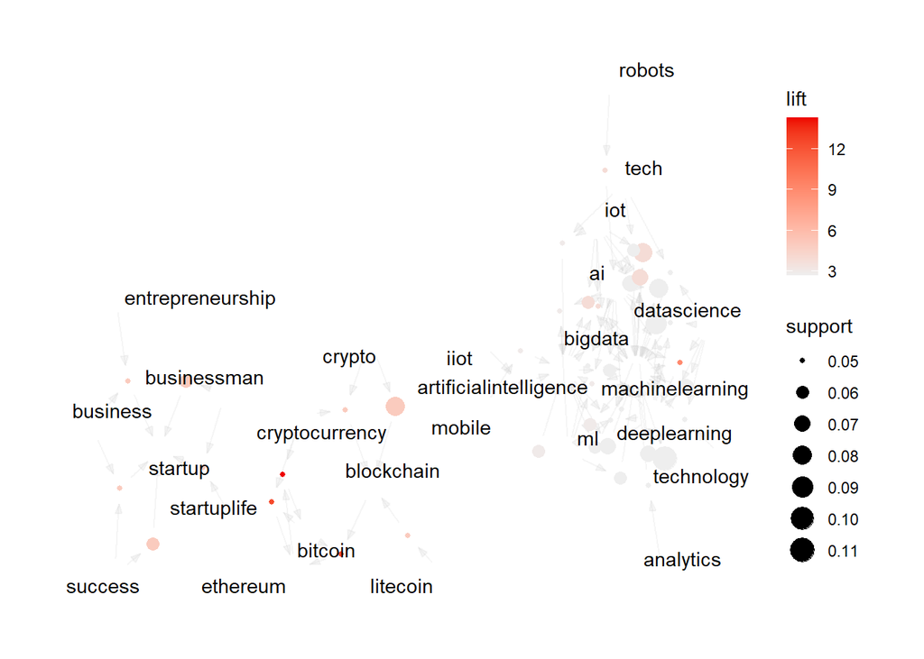

```r
plot(rules, method="graph", measure="support", shading="lift", main="Rules")
```

```r
summary(rules)
```

```
## set of 46 rules
##
## rule length distribution (lhs + rhs):sizes
##  2  3  4  5
## 11 21 12  2
##
##    Min. 1st Qu.  Median    Mean 3rd Qu.    Max.
##   2.000   3.000   3.000   3.109   4.000   5.000
##
## summary of quality measures:
##     support          confidence    coverage            lift
##  Min.   :0.05000   Min.   :1    Min.   :0.05000   Min.   : 2.703
##  1st Qu.:0.05000   1st Qu.:1    1st Qu.:0.05000   1st Qu.: 2.703
##  Median :0.05000   Median :1    Median :0.05000   Median : 2.941
##  Mean   :0.05848   Mean   :1    Mean   :0.05848   Mean   : 4.079
##  3rd Qu.:0.06000   3rd Qu.:1    3rd Qu.:0.06000   3rd Qu.: 4.712
##  Max.   :0.11000   Max.   :1    Max.   :0.11000   Max.   :14.286
##      count
##  Min.   : 5.000
##  1st Qu.: 5.000
##  Median : 5.000
##  Mean   : 5.848
##  3rd Qu.: 6.000
##  Max.   :11.000
##
## mining info:
##      data ntransactions support confidence
##  hashtags           100    0.05          1
##                                                               call
##  apriori(data = hashtags, parameter = list(supp = 0.05, conf = 1))
```

```r
inspect(sort(rules, by = "support")[1:5])
```

```
##     lhs                       rhs               support confidence coverage
## [1] {deeplearning}         => {machinelearning} 0.11    1          0.11
## [2] {ai, deeplearning}     => {machinelearning} 0.09    1          0.09
## [3] {crypto}               => {blockchain}      0.08    1          0.08
## [4] {iot, machinelearning} => {ai}              0.08    1          0.08
## [5] {ai, bigdata}          => {machinelearning} 0.08    1          0.08
##     lift     count
## [1] 2.702703 11
## [2] 2.702703  9
## [3] 5.000000  8
## [4] 3.846154  8
## [5] 2.702703  8
```

```r
inspect(sort(rules, by = "confidence")[1:5])
```

```
##     lhs            rhs                      support confidence coverage
## [1] {analytics} => {machinelearning}        0.05    1          0.05
## [2] {mobile}    => {artificialintelligence} 0.05    1          0.05
## [3] {iiot}      => {artificialintelligence} 0.05    1          0.05
## [4] {litecoin}  => {blockchain}             0.05    1          0.05
## [5] {robots}    => {ai}                     0.05    1          0.05
##     lift     count
## [1] 2.702703 5
## [2] 2.941176 5
## [3] 2.941176 5
## [4] 5.000000 5
## [5] 3.846154 5
```

```r
inspect(sort(rules, by = "lift")[1:5])
```

```
##     lhs                  rhs            support confidence coverage      lift count
## [1] {cryptocurrency,
##      ethereum}        => {bitcoin}         0.05          1     0.05 14.285714     5
## [2] {bitcoin,
##      cryptocurrency}  => {ethereum}        0.05          1     0.05 12.500000     5
## [3] {bitcoin,
##      blockchain}      => {ethereum}        0.05          1     0.05 12.500000     5
## [4] {bigdata,
##      datascience,
##      machinelearning} => {deeplearning}    0.05          1     0.05  9.090909     5
## [5] {litecoin}        => {blockchain}      0.05          1     0.05  5.000000     5
```

```r
inspect(sort(rules, by = "count")[1:5])
```

```
##     lhs                       rhs               support confidence coverage
## [1] {deeplearning}         => {machinelearning} 0.11    1          0.11
## [2] {ai, deeplearning}     => {machinelearning} 0.09    1          0.09
## [3] {crypto}               => {blockchain}      0.08    1          0.08
## [4] {iot, machinelearning} => {ai}              0.08    1          0.08
## [5] {ai, bigdata}          => {machinelearning} 0.08    1          0.08
##     lift     count
## [1] 2.702703 11
## [2] 2.702703  9
## [3] 5.000000  8
## [4] 3.846154  8
## [5] 2.702703  8
```

We can see, that items with highest support and confidence are related to machinelearning, where the highest support = 11% is between deeplearning and machinelearning, which means the pair of those two hashtags appears in 11% of all posts.

On the other hand the highest Lift is in hashtags related to cryptocurrencies A lift of 14.28 indicates that the occurrence of {cryptocurrency, ethereum} and {bitcoin} together is 14.28 times more than what would be expected if the occurrence of these hashtags was independent. This strong association suggests that posts or content related to cryptocurrency, ethereum, and bitcoin are highly likely to be connected or co-occur in the context of social media or online content

## rhs and lhs analysis

to perform association rules for left and right side lets first create funtions:

```r
generate_rules_rhs <- function(data, rhs_item, min_support = 0.01, min_confidence = 0.005) {
  rules <- apriori(
    data = data,
    parameter = list(supp = min_support, conf = min_confidence),
    appearance = list(default = "lhs", rhs = rhs_item),
    control = list(verbose = FALSE)
  )
  rules_sorted <- sort(rules, by = "confidence", decreasing = TRUE)
  return(rules_sorted)
}

generate_rules_lhs <- function(data, lhs_item, min_support = 0.01, min_confidence = 0.005) {
  rules <- apriori(
    data = data,
    parameter = list(supp = min_support, conf = min_confidence),
    appearance = list(default = "rhs", lhs = lhs_item),
    control = list(verbose = FALSE)
  )
  rules_sorted <- sort(rules, by = "confidence", decreasing = TRUE)
  return(rules_sorted)
}
```

And now lets check both rhs and lhs rules for some hashtags

```r
rules_ai_rhs <- generate_rules_rhs(data = hashtags, rhs_item = 'ai',min_support = 0.05, min_confidence = 0.8)
rules_ai_lhs <- generate_rules_lhs(data = hashtags, lhs_item = 'ai',min_support = 0.05, min_confidence = 0.8)

rules_bitcoin_rhs <- generate_rules_rhs(data = hashtags, rhs_item = 'bitcoin',min_support = 0.05, min_confidence = 0.8)
rules_bitcoin_lhs <- generate_rules_lhs(data = hashtags, lhs_item = 'bitcoin',min_support = 0.05, min_confidence = 0.8)

rules_bigdata_rhs <- generate_rules_rhs(data = hashtags, rhs_item = 'bigdata',min_support = 0.05, min_confidence = 0.8)
rules_bigdata_lhs <- generate_rules_lhs(data = hashtags, lhs_item = 'bigdata',min_support = 0.05, min_confidence = 0.8)

rules_startup_rhs <- generate_rules_rhs(data = hashtags, rhs_item = 'startup',min_support = 0.05, min_confidence = 0.8)
rules_startup_lhs <- generate_rules_lhs(data = hashtags, lhs_item = 'startup',min_support = 0.05, min_confidence = 0.8)
```

```r
inspect(sort(rules_ai_rhs, by = "confidence"), linebreak = FALSE)
```

```
##      lhs                                                        rhs  support
## [1]  {robots}                                                => {ai} 0.05
## [2]  {iot, machinelearning}                                  => {ai} 0.08
## [3]  {bigdata, iot, machinelearning}                         => {ai} 0.07
## [4]  {artificialintelligence, iot, machinelearning}          => {ai} 0.06
## [5]  {artificialintelligence, bigdata, iot, machinelearning} => {ai} 0.05
## [6]  {bigdata, iot}                                          => {ai} 0.07
## [7]  {artificialintelligence, deeplearning}                  => {ai} 0.06
## [8]  {artificialintelligence, deeplearning, machinelearning} => {ai} 0.06
## [9]  {ml}                                                    => {ai} 0.05
## [10] {robotics}                                              => {ai} 0.05
## [11] {artificialintelligence, ml}                            => {ai} 0.05
## [12] {machinelearning, ml}                                   => {ai} 0.05
## [13] {artificialintelligence, machinelearning, ml}           => {ai} 0.05
## [14] {artificialintelligence, bigdata, iot}                  => {ai} 0.05
```

[output cut: 21 more lines]

```r
inspect(sort(rules_ai_lhs, by = "confidence"), linebreak = FALSE)
```

```
##     lhs     rhs               support confidence coverage lift     count
## [1] {ai} => {machinelearning} 0.21    0.8076923  0.26     2.182952 21
```

```r
inspect(sort(rules_bitcoin_rhs, by = "confidence"), linebreak = FALSE)
```

```
##     lhs                           rhs       support confidence coverage
## [1] {cryptocurrency, ethereum} => {bitcoin} 0.05    1          0.05
##     lift     count
## [1] 14.28571 5
```

```r
inspect(sort(rules_bitcoin_lhs, by = "confidence"), linebreak = FALSE)
```

```
##     lhs          rhs        support confidence coverage lift     count
## [1] {bitcoin} => {ethereum} 0.06    0.8571429  0.07     10.71429 6
```

```r
inspect(sort(rules_bigdata_rhs, by = "confidence"), linebreak = FALSE)
```

```
##     lhs                                                   rhs       support
## [1] {iot, machinelearning}                             => {bigdata} 0.07
## [2] {ai, iot, machinelearning}                         => {bigdata} 0.07
## [3] {artificialintelligence, iot, machinelearning}     => {bigdata} 0.05
## [4] {ai, artificialintelligence, iot, machinelearning} => {bigdata} 0.05
##     confidence coverage lift     count
## [1] 0.8750000  0.08     5.833333 7
## [2] 0.8750000  0.08     5.833333 7
## [3] 0.8333333  0.06     5.555556 5
## [4] 0.8333333  0.06     5.555556 5
```

```r
inspect(sort(rules_bigdata_lhs, by = "confidence"), linebreak = FALSE)
```

```
##     lhs          rhs               support confidence coverage lift     count
## [1] {bigdata} => {machinelearning} 0.12    0.8        0.15     2.162162 12
```

```r
inspect(sort(rules_startup_rhs, by = "confidence"), linebreak = FALSE)
```

```
##     lhs                                 rhs       support confidence coverage
## [1] {success}                        => {startup} 0.06    1.0000000  0.06
## [2] {businessman}                    => {startup} 0.06    1.0000000  0.06
## [3] {business, success}              => {startup} 0.05    1.0000000  0.05
## [4] {businessman, startuplife}       => {startup} 0.05    1.0000000  0.05
## [5] {business, entrepreneurship}     => {startup} 0.05    1.0000000  0.05
## [6] {entrepreneur}                   => {startup} 0.06    0.8571429  0.07
## [7] {startuplife}                    => {startup} 0.06    0.8571429  0.07
## [8] {entrepreneur, entrepreneurship} => {startup} 0.05    0.8333333  0.06
##     lift     count
## [1] 5.000000 6
## [2] 5.000000 6
## [3] 5.000000 5
## [4] 5.000000 5
## [5] 5.000000 5
## [6] 4.285714 6
## [7] 4.285714 6
## [8] 4.166667 5
```

```r
inspect(sort(rules_startup_lhs, by = "confidence"), linebreak = FALSE)
```

[output not shown]

We can see that some hashtags have much more rules than the other, but all are selected to be confident at level of at least 80%.

## Rules for followers count

Analysis above were only performed to find rules across hashtags, now I want to change the focus. I want to find whether the length of Caption or number of Hashtags has an impact on Follower count.

Lets create rules for that:

```r
rules.followers <- apriori(data = data, parameter=list(supp=0.05,conf = 0.7))
```

```
## Apriori
##
## Parameter specification:
##  confidence minval smax arem  aval originalSupport maxtime support minlen
##         0.7    0.1    1 none FALSE            TRUE       5    0.05      1
##  maxlen target  ext
##      10  rules TRUE
##
## Algorithmic control:
##  filter tree heap memopt load sort verbose
##     0.1 TRUE TRUE  FALSE TRUE    2    TRUE
##
## Absolute minimum support count: 5
##
## set item appearances ...[0 item(s)] done [0.00s].
## set transactions ...[16 item(s), 100 transaction(s)] done [0.00s].
## sorting and recoding items ... [16 item(s)] done [0.00s].
## creating transaction tree ... done [0.00s].
## checking subsets of size 1 2 3 4 done [0.00s].
## writing ... [11 rule(s)] done [0.00s].
## creating S4 object  ... done [0.00s].
```

```r
rules.followers.byconf <- sort(rules.followers, by="confidence", decreasing=T)
inspect(rules.followers.byconf)
```

```
##      lhs                              rhs                        support confidence coverage     lift count
## [1]  {Followers=small (<200),
##       Likes=low (<50)}             => {Caption=medium (<200)}       0.05  0.8333333     0.06 1.893939     5
## [2]  {Caption=long (>200),
##       Followers=medium (<1000),
##       Hashtags=large (>25)}        => {Likes=low (<50)}             0.05  0.8333333     0.06 1.633987     5
## [3]  {Caption=long (>200),
##       Followers=medium (<1000)}    => {Likes=low (<50)}             0.08  0.8000000     0.10 1.568627     8
## [4]  {Followers=very small (<100)} => {Hashtags=big (<25)}          0.07  0.7777778     0.09 2.356902     7
## [5]  {Caption=short (<50),
##       Hashtags=big (<25)}          => {Likes=low (<50)}             0.06  0.7500000     0.08 1.470588     6
## [6]  {Caption=short (<50),
##       Hashtags=large (>25)}        => {Followers=medium (<1000)}    0.12  0.7500000     0.16 1.666667    12
## [7]  {Hashtags=low (<5)}           => {Caption=medium (<200)}       0.05  0.7142857     0.07 1.623377     5
## [8]  {Caption=short (<50),
##       Followers=large (>2000)}     => {Likes=low (<50)}             0.05  0.7142857     0.07 1.400560     5
## [9]  {Followers=large (>2000),
##       Likes=low (<50)}             => {Caption=short (<50)}         0.05  0.7142857     0.07 2.463054     5
## [10] {Caption=long (>200),
##       Hashtags=large (>25),
##       Likes=low (<50)}             => {Followers=medium (<1000)}    0.05  0.7142857     0.07 1.587302     5
## [11] {Caption=short (<50),
##       Followers=medium (<1000)}    => {Hashtags=large (>25)}        0.12  0.7058824     0.17 1.604278    12
```

There are 11 rules but already with the highest confidence ([2]) we can see that with 83% confidence Posts that have long Caption and Large amount of Hashtags get low Likes.

Let’s plot the reulst:

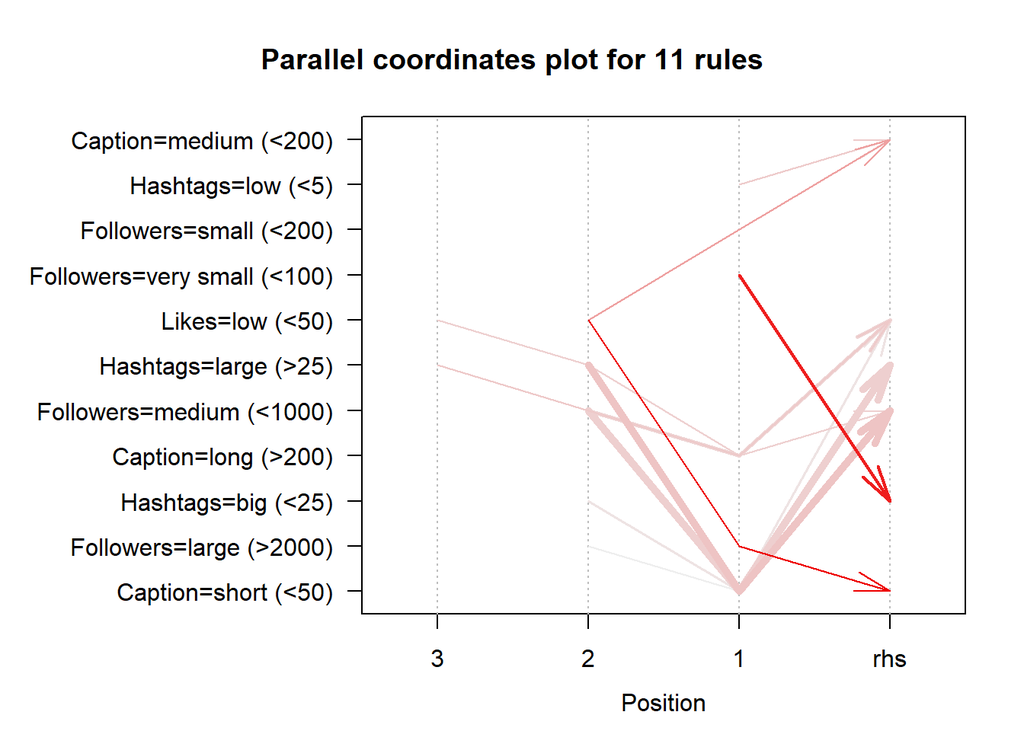

```r
plot(rules.followers, method='paracoord', control=list(reorder=T))
```

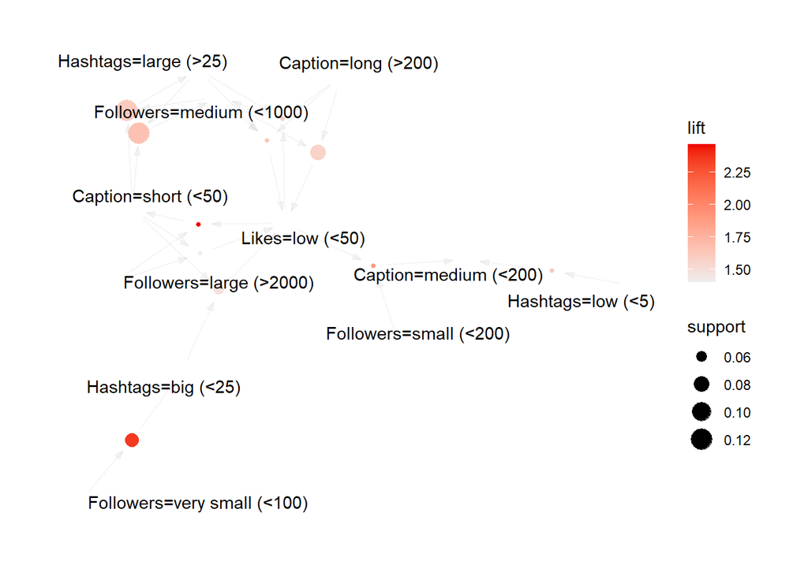

```r
plot(rules.followers, method="graph")
```

In the center we can see that both Big hashtag number and long caption lead to low Likes number.

## Rules for large number of hashtags

```r
print(sum(data$Hashtags == 'large (>25)'))
```

```
## [1] 44
```

In the dataset there is 44 posts with a large number of hashtags. Therefore we can check if many hashtags lead to higher number of followers or likes.

```r
large.hashtag.data <- data[data$Hashtags == 'large (>25)', ]
rules.large.hashtag <- apriori(data = large.hashtag.data, parameter=list(supp=0.5,conf = 1))
```

```
## Apriori
##
## Parameter specification:
##  confidence minval smax arem  aval originalSupport maxtime support minlen
##           1    0.1    1 none FALSE            TRUE       5     0.5      1
##  maxlen target  ext
##      10  rules TRUE
##
## Algorithmic control:
##  filter tree heap memopt load sort verbose
##     0.1 TRUE TRUE  FALSE TRUE    2    TRUE
##
## Absolute minimum support count: 22
##
## set item appearances ...[0 item(s)] done [0.00s].
## set transactions ...[13 item(s), 44 transaction(s)] done [0.00s].
## sorting and recoding items ... [3 item(s)] done [0.00s].
## creating transaction tree ... done [0.00s].
## checking subsets of size 1 2 done [0.00s].
## writing ... [3 rule(s)] done [0.00s].
## creating S4 object  ... done [0.00s].
```

```r
rules.large.hashtag.byconf <- sort(rules.large.hashtag, by="confidence", decreasing=T)
inspect(rules.large.hashtag.byconf)
```

```
##     lhs                           rhs                    support   confidence
## [1] {}                         => {Hashtags=large (>25)} 1.0000000 1
## [2] {Followers=medium (<1000)} => {Hashtags=large (>25)} 0.5681818 1
## [3] {Likes=low (<50)}          => {Hashtags=large (>25)} 0.5909091 1
##     coverage  lift count
## [1] 1.0000000 1    44
## [2] 0.5681818 1    25
## [3] 0.5909091 1    26
```

We see only three rules with confidence 1 so they appear in every example. What is interesting the large amount of hashtags being used dont lead to higher number of likes

## Rules for low number of likes

```r
print(sum(data$Likes == 'very low (<20)'))
```

```
## [1] 28
```

We can see 28 posts where the number of likes is low. Let’s find out what rules posts that get under 20 likes follow.

```r
vlow.likes.data <- data[data$Likes == 'very low (<20)', ]
rules.vlow.hashtag <- apriori(data = vlow.likes.data, parameter=list(supp=0.5,conf = 0.5))
```

```
## Apriori
##
## Parameter specification:
##  confidence minval smax arem  aval originalSupport maxtime support minlen
##         0.5    0.1    1 none FALSE            TRUE       5     0.5      1
##  maxlen target  ext
##      10  rules TRUE
##
## Algorithmic control:
##  filter tree heap memopt load sort verbose
##     0.1 TRUE TRUE  FALSE TRUE    2    TRUE
##
## Absolute minimum support count: 14
##
## set item appearances ...[0 item(s)] done [0.00s].
## set transactions ...[13 item(s), 28 transaction(s)] done [0.00s].
## sorting and recoding items ... [3 item(s)] done [0.00s].
## creating transaction tree ... done [0.00s].
## checking subsets of size 1 2 done [0.00s].
## writing ... [7 rule(s)] done [0.00s].
## creating S4 object  ... done [0.00s].
```

```r
rules.vlow.hashtag.byconf <- sort(rules.vlow.hashtag, by="confidence", decreasing=T)
inspect(rules.vlow.hashtag.byconf)
```

```
##     lhs                        rhs                     support   confidence
## [1] {}                      => {Likes=very low (<20)}  1.0000000 1.0000000
## [2] {Hashtags=big (<25)}    => {Likes=very low (<20)}  0.5000000 1.0000000
## [3] {Caption=medium (<200)} => {Likes=very low (<20)}  0.5714286 1.0000000
## [4] {}                      => {Caption=medium (<200)} 0.5714286 0.5714286
## [5] {Likes=very low (<20)}  => {Caption=medium (<200)} 0.5714286 0.5714286
## [6] {}                      => {Hashtags=big (<25)}    0.5000000 0.5000000
## [7] {Likes=very low (<20)}  => {Hashtags=big (<25)}    0.5000000 0.5000000
##     coverage  lift count
## [1] 1.0000000 1    28
## [2] 0.5000000 1    14
## [3] 0.5714286 1    16
## [4] 1.0000000 1    16
## [5] 1.0000000 1    16
## [6] 1.0000000 1    14
## [7] 1.0000000 1    14
```

Again we can see, that hashtags don’t influence the number of likes.

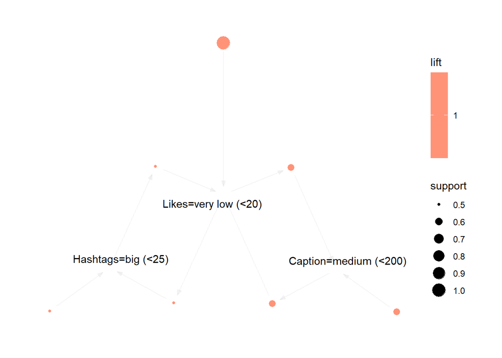

```r
plot(rules.vlow.hashtag, method="graph")
```

# Conclusion

Understanding the hidden patterns in the data can provide insights that could have influence on our decisions, and with association rules we can achieve it. Apriori algorithms that can transform complex datasets into easily understandable outputs can be adventageous in various life or business settings. The data used in this project was used to find what hashtags people use when speaking of ‘IT’ topics on instagram. The paper also showed what some specifics of the post say about its outcome (in case of likes/follows). The used dataset was small with only 100 different posts, but in them there were 1157 different hashtags used. The study shows, that the most popular hashtags in the data were ‘#machinelearning’ and ‘#artificialintelligence’, which is strange as those are the longest.

[^1]: https://www.kaggle.com/code/vanvalkenberg/instagram-reach-eda-predictive-modelling/input
[^2]: https://www.javatpoint.com/apriori-algorithm-in-machine-learning